# Predict manner of the exercise

## introduction

This document is project course of “Practical Machine Learning”.

#### Backgroud

The backgroud is decribed in project backgroud: using devices such as Jawbone Up, Nike FuelBand, and Fitbit it is now possible to collect a large amount of data about personal activity relatively inexpensively. These type of devices are part of the quantified self movement – a group of enthusiasts who take measurements about themselves regularly to improve their health, to find patterns in their behavior, or because they are tech geeks. One thing that people regularly do is quantify how much of a particular activity they do, but they rarely quantify how well they do it.

#### goal

The goal of this project is to use data given to fit a classification model for 5 different active way. The data used come from accelerometers on the belt, forearm, arm, and dumbell of 6 participants, who were asked to perform barbell lifts correctly and incorrectly in 5 different ways.

## Data preProcessing

Read the data from files

```r
library(caret)
library(randomForest)
tmp_ds<-read.csv("pml-training.csv", na.strings=c("NA","","#DIV/0!"))
```

#### train/valid data split

To test the classifier, random subsampling cross-validation is used to split input training data into training subset and validation subset.

```r
set.seed(12345)
inTrain = createDataPartition(tmp_ds$classe, p = 0.75)[[1]]
train_ds = tmp_ds[ inTrain, ]
valid_ds = tmp_ds[-inTrain, ]
dim(train_ds)
```

```
## [1] 14718   160
```

```r
dim(valid_ds)
```

```
## [1] 4904  160
```

#### Business varaible selection

```r
summary(train_ds)
```

As described in 2013.Velloso.QAR-WLE.pdf, there are four sensors on belt, arm, dumbbell and forearm. Every case in the dataset has a group of variables for each of the four sensors, which are the raw accelerometer, gyroscope and magnetometer readings and calculated Euler angles (roll, pitch and yaw). And for the Euler angles of each of the four sensors eight statistics features were calculated such as mean, max, min and so on.

So, The Euler angles and raw accelerometer, gyroscope and magnetometer readings of four sensors are taken out only to predict.

```r
var_list<-c(8:11,37:45,46:49,60:68,84:86,102,113:121,122:124,140,151:159)
train_classe<-train_ds[,160]
train_ds<-train_ds[,var_list]

valid_classe<-valid_ds[,160]
valid_ds<-valid_ds[,var_list]
```

#### zero covariates remove

Try to remove zero covariates

```r
nsv<-nearZeroVar(train_ds, saveMetrics=TRUE)
nsv
```

```
##                      freqRatio percentUnique zeroVar   nzv
## roll_belt             1.090511     7.6776736   FALSE FALSE
## pitch_belt            1.026490    11.6252208   FALSE FALSE
## yaw_belt              1.077922    12.3929882   FALSE FALSE
## total_accel_belt      1.064708     0.1970376   FALSE FALSE
## gyros_belt_x          1.056365     0.9036554   FALSE FALSE
## gyros_belt_y          1.151554     0.4484305   FALSE FALSE
## gyros_belt_z          1.077158     1.1346650   FALSE FALSE
## accel_belt_x          1.022034     1.0667210   FALSE FALSE
## accel_belt_y          1.092624     0.9376274   FALSE FALSE
## accel_belt_z          1.111635     1.9839652   FALSE FALSE
## magnet_belt_x         1.025830     2.0383204   FALSE FALSE
## magnet_belt_y         1.117400     1.9703764   FALSE FALSE
## magnet_belt_z         1.011527     2.9555646   FALSE FALSE
## roll_arm             53.872340    16.7278163   FALSE FALSE
## pitch_arm            87.344828    19.3640440   FALSE FALSE
## yaw_arm              31.650000    18.2769398   FALSE FALSE
## total_accel_arm       1.004405     0.4484305   FALSE FALSE
## gyros_arm_x           1.020619     4.2804729   FALSE FALSE
## gyros_arm_y           1.418136     2.5207229   FALSE FALSE
## gyros_arm_z           1.127182     1.6034787   FALSE FALSE
## accel_arm_x           1.007937     5.2248947   FALSE FALSE
## accel_arm_y           1.095808     3.5738551   FALSE FALSE
## accel_arm_z           1.030000     5.2181003   FALSE FALSE
## magnet_arm_x          1.046875     9.0229651   FALSE FALSE
## magnet_arm_y          1.158730     5.8228020   FALSE FALSE
## magnet_arm_z          1.022727     8.5133850   FALSE FALSE
## roll_dumbbell         1.054348    86.2617203   FALSE FALSE
## pitch_dumbbell        2.510870    83.9584183   FALSE FALSE
## yaw_dumbbell          1.069767    85.5347194   FALSE FALSE
## total_accel_dumbbell  1.072835     0.2853649   FALSE FALSE
## gyros_dumbbell_x      1.027660     1.6170675   FALSE FALSE
## gyros_dumbbell_y      1.180000     1.8412828   FALSE FALSE
## gyros_dumbbell_z      1.065760     1.3656747   FALSE FALSE
## accel_dumbbell_x      1.015326     2.7992934   FALSE FALSE
## accel_dumbbell_y      1.101695     3.1118358   FALSE FALSE
## accel_dumbbell_z      1.049724     2.7381438   FALSE FALSE
## magnet_dumbbell_x     1.156250     7.3855143   FALSE FALSE
## magnet_dumbbell_y     1.109375     5.6665308   FALSE FALSE
## magnet_dumbbell_z     1.104478     4.5318657   FALSE FALSE
## roll_forearm         11.656126    13.2219052   FALSE FALSE
## pitch_forearm        64.065217    18.1410518   FALSE FALSE
## yaw_forearm          14.883838    12.3114554   FALSE FALSE
## total_accel_forearm   1.127273     0.4552249   FALSE FALSE
## gyros_forearm_x       1.010050     1.9635820   FALSE FALSE
## gyros_forearm_y       1.027875     4.8919690   FALSE FALSE
## gyros_forearm_z       1.064343     1.9839652   FALSE FALSE
## accel_forearm_x       1.131148     5.3268107   FALSE FALSE
## accel_forearm_y       1.013333     6.6449246   FALSE FALSE
## accel_forearm_z       1.008333     3.7980704   FALSE FALSE
## magnet_forearm_x      1.033333     9.9741813   FALSE FALSE
## magnet_forearm_y      1.208955    12.4269602   FALSE FALSE
## magnet_forearm_z      1.045455    11.1088463   FALSE FALSE
```

No feature should be removed.

#### high Correlation variables remove

check high Correlation variables

```r
highCorr<-findCorrelation(cor(train_ds), 0.90)
highCorr
```

```
## [1] 10  1  9  8 19 46 31
```

Remove high Correlation variables

```r
train_ds<-train_ds[,-highCorr]
valid_ds<-valid_ds[,-highCorr]
```

#### standardize and NA value remove

```r
Process <- preProcess(train_ds)
trainPC <- predict(Process, train_ds)
```

## Model selection

```r
ctrl<-rfeControl(functions=rfFuncs, method="cv",repeats=3, returnResamp="all")
rfProfile <- rfe(trainPC, train_classe, sizes=c(1:ncol(trainPC)), rfeControl = ctrl)
rfProfile
```

```
##
## Recursive feature selection
##
## Outer resampling method: Cross-Validated (10 fold)
##
## Resampling performance over subset size:
##
##  Variables Accuracy  Kappa AccuracySD  KappaSD Selected
##          1   0.5580 0.4372   0.010617 0.013297
##          2   0.7870 0.7305   0.012550 0.015853
##          3   0.9056 0.8805   0.005598 0.007137
##          4   0.9517 0.9389   0.008009 0.010171
##          5   0.9711 0.9635   0.004872 0.006163
##          6   0.9734 0.9663   0.007556 0.009567
##          7   0.9770 0.9709   0.007558 0.009563
```

[output cut: 41 more lines]

As resampling data and below plots described, the accuracies increase very very slowly when the number of variables is larger than 20. Although I don’t think the variables in final model are too much, I think I could do further feature selection to reduce the features, with my own selection function wth my own selection condiction, e.g., instead of selection is with max accuracy decrease, selection with the least features and accuracy > thresh, e.g. 0.99.

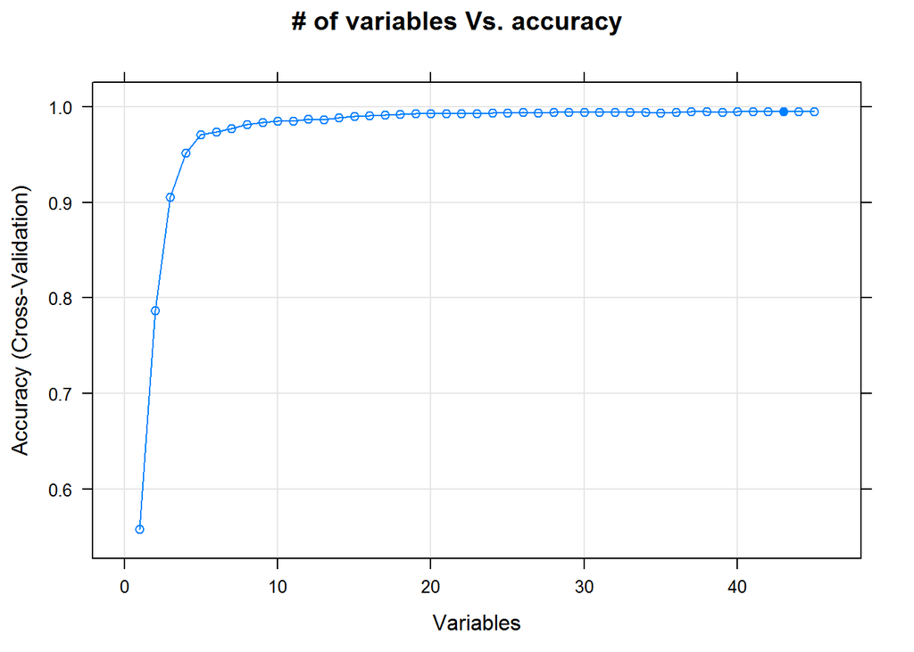

```r
plot(rfProfile,type=c('o','g'), main = "# of variables Vs. accuracy")
```

The predictors in the final model are:

```r
predictors(rfProfile)
```

```
##  [1] "yaw_belt"             "magnet_dumbbell_z"    "pitch_belt"
##  [4] "magnet_dumbbell_y"    "pitch_forearm"        "magnet_belt_y"
##  [7] "gyros_belt_z"         "magnet_forearm_z"     "magnet_belt_z"
## [10] "accel_dumbbell_y"     "roll_arm"             "roll_dumbbell"
## [13] "accel_dumbbell_z"     "roll_forearm"         "magnet_dumbbell_x"
## [16] "magnet_belt_x"        "yaw_arm"              "gyros_forearm_y"
## [19] "gyros_arm_x"          "accel_forearm_x"      "accel_forearm_z"
## [22] "yaw_dumbbell"         "total_accel_dumbbell" "magnet_arm_z"
## [25] "magnet_forearm_y"     "total_accel_belt"     "gyros_dumbbell_y"
## [28] "accel_forearm_y"      "pitch_arm"            "yaw_forearm"
## [31] "accel_arm_y"          "accel_dumbbell_x"     "gyros_dumbbell_z"
## [34] "accel_arm_z"          "total_accel_forearm"  "magnet_forearm_x"
## [37] "gyros_belt_x"         "total_accel_arm"      "accel_arm_x"
## [40] "gyros_belt_y"         "magnet_arm_x"         "gyros_forearm_x"
## [43] "magnet_arm_y"
```

Predict the valid data and the check the accuracy:

```r
validPC <- predict(Process, valid_ds)
pred<-predict(rfProfile, validPC)
postResample(pred, valid_classe)
```

```
##  Accuracy     Kappa
## 0.9944943 0.9930352
```

```r
confusionMatrix(pred$pred,valid_classe)
```

```
## Confusion Matrix and Statistics
##
##           Reference
## Prediction    A    B    C    D    E
##          A 1395    6    0    0    0
##          B    0  937    4    0    0
##          C    0    6  851    6    1
##          D    0    0    0  798    4
##          E    0    0    0    0  896
##
## Overall Statistics
##
##                Accuracy : 0.9945
##                  95% CI : (0.992, 0.9964)
##     No Information Rate : 0.2845
##     P-Value [Acc > NIR] : < 2.2e-16
##
##                   Kappa : 0.993
##  Mcnemar's Test P-Value : NA
##
## Statistics by Class:
##
##                      Class: A Class: B Class: C Class: D Class: E
## Sensitivity            1.0000   0.9874   0.9953   0.9925   0.9945
## Specificity            0.9983   0.9990   0.9968   0.9990   1.0000
## Pos Pred Value         0.9957   0.9957   0.9850   0.9950   1.0000
## Neg Pred Value         1.0000   0.9970   0.9990   0.9985   0.9988
## Prevalence             0.2845   0.1935   0.1743   0.1639   0.1837
## Detection Rate         0.2845   0.1911   0.1735   0.1627   0.1827
## Detection Prevalence   0.2857   0.1919   0.1762   0.1635   0.1827
## Balanced Accuracy      0.9991   0.9932   0.9961   0.9958   0.9972
```

So, the accuracy is 0.9945 and the out of sample errors is expected to be 0.0055( = 1-accuracy)

#### futher feature selection with my own function

Use backword with the ordered importance to select the features and set the accuracy thresh.

```r
acc_thresh<-0.99
acc_list<-{}
remove_flist<-{}
importance_list<-{}
```

```r
ModFit1<-randomForest(train_classe ~ ., trainPC)
pred<-predict(ModFit1, validPC)

while ((confusionMatrix(valid_classe, pred)$overall)[1]>acc_thresh) {
   vImp<-varImp(ModFit1)
   # store the infomation of current model
   acc_list<-c(acc_list, (confusionMatrix(valid_classe, pred)$overall)[1])
   importance_list<-c(importance_list, min(vImp))
   min_acc_predictor<-which(vImp$Overall==min(vImp))
   remove_flist<- c(remove_flist, rownames(vImp)[min_acc_predictor])

   # get the feature except the one with min imporatance
   remain_predictor<-rownames(vImp)[-min_acc_predictor]

   ModFit1<-randomForest(train_classe ~ ., trainPC[,remain_predictor])
   pred<-predict(ModFit1, validPC)
}
data.frame(importance=round(importance_list,4), var=remove_flist, accuracy=round(acc_list,4), row.names=c(ncol(trainPC):(ncol(trainPC) - length(remove_flist)+1)))
```

```
##    importance                  var accuracy
## 45    56.4333          gyros_arm_z   0.9951
## 44    75.1856      gyros_forearm_x   0.9951
## 43    85.3559     gyros_dumbbell_z   0.9945
## 42    84.3566      total_accel_arm   0.9949
## 41   106.4023  total_accel_forearm   0.9939
## 40   109.2214         gyros_belt_x   0.9941
## 39   117.0910         gyros_belt_y   0.9937
## 38   129.5588      gyros_forearm_y   0.9937
## 37   129.7947          accel_arm_z   0.9935
## 36   139.1525      accel_forearm_y   0.9941
## 35   154.9944          gyros_arm_x   0.9931
## 34   167.5188            pitch_arm   0.9933
## 33   169.5172          yaw_forearm   0.9931
## 32   174.9465       pitch_dumbbell   0.9925
```

[output cut: 16 more lines]

The model seletion stop at accuracy=0.9892. The final model is the one before the last

```r
remain_predictor<-rownames(vImp)
ModFit1<-randomForest(train_classe ~ ., trainPC[,remain_predictor])
pred<-predict(ModFit1, validPC)
```

There are 16 features in the final model:

```
##  [1] "pitch_belt"        "yaw_belt"          "gyros_belt_z"
##  [4] "magnet_belt_y"     "magnet_belt_z"     "roll_arm"
##  [7] "roll_dumbbell"     "accel_dumbbell_y"  "accel_dumbbell_z"
## [10] "magnet_dumbbell_x" "magnet_dumbbell_y" "magnet_dumbbell_z"
## [13] "roll_forearm"      "pitch_forearm"     "accel_forearm_x"
## [16] "magnet_forearm_z"
```

The final model’s accuracy is 0.991 and out of sample errors is 0.009 (= 1- accuracy):

```r
confusionMatrix(pred, valid_classe)
```

```
## Confusion Matrix and Statistics
##
##           Reference
## Prediction    A    B    C    D    E
##          A 1392    9    0    0    0
##          B    3  931    7    0    0
##          C    0    9  843    5    3
##          D    0    0    5  799    3
##          E    0    0    0    0  895
##
## Overall Statistics
##
##                Accuracy : 0.991
##                  95% CI : (0.988, 0.9935)
##     No Information Rate : 0.2845
##     P-Value [Acc > NIR] : < 2.2e-16
##
##                   Kappa : 0.9887
##  Mcnemar's Test P-Value : NA
##
## Statistics by Class:
##
##                      Class: A Class: B Class: C Class: D Class: E
## Sensitivity            0.9978   0.9810   0.9860   0.9938   0.9933
## Specificity            0.9974   0.9975   0.9958   0.9980   1.0000
## Pos Pred Value         0.9936   0.9894   0.9802   0.9901   1.0000
## Neg Pred Value         0.9991   0.9955   0.9970   0.9988   0.9985
## Prevalence             0.2845   0.1935   0.1743   0.1639   0.1837
## Detection Rate         0.2838   0.1898   0.1719   0.1629   0.1825
## Detection Prevalence   0.2857   0.1919   0.1754   0.1646   0.1825
## Balanced Accuracy      0.9976   0.9893   0.9909   0.9959   0.9967
```

## predict test data

```r
test_ds<-read.csv("pml-testing.csv", na.strings=c("NA","","#DIV/0!"))
test_ds<-test_ds[,var_list]
test_ds<-test_ds[,-highCorr]
testPC <- predict(Process, test_ds)
predTest<-predict(ModFit1, testPC)
```

## References

#### online data link

- The training data for this project are available here:

https://d396qusza40orc.cloudfront.net/predmachlearn/pml-training.csv

- The test data are available here:

https://d396qusza40orc.cloudfront.net/predmachlearn/pml-testing.csv

#### data citation

- 2013.Velloso.QAR-WLE.pdf

The data for this project come from this source: http://groupware.les.inf.puc-rio.br/har.